# MA22004

05/11/2020

## Announcements

### Reminders

- It is week 4! You should have read the remainder of §3 of the notes on **Perusall**.
- Feedback for Lab 2 is posted.

### Upcoming

- Lab 3 due **Thursday 5 Nov** at **17:00**: upload to **Gradescope**; late submissions will be accepted until Sat 7 Nov at 13:00.
- Worksheet #5 (Two sample inferences) is on **Blackboard**: start before next workshop (should last two weeks).
- Investigation #4 on **Perusall**: do before next workshop.
- Reading assignment #6 (rest of §4) on **Perusall**: do before next seminar.

## Inferences for means based on two samples

Today we compare **means** based on two samples from different groups.

E.g., \[\overline{X} = \frac{1}{m} \sum_{i=1}^m X_i \,, \qquad X_1, \dots, X_m \sim \mathsf{N}(\mu_X, \sigma_X^2)\] \[\overline{Y} = \frac{1}{n} \sum_{i=1}^n Y_i \,, \qquad Y_1, \dots, Y_n \sim \mathsf{N}(\mu_Y, \sigma_Y^2)\]

## Two types of sampling

Comparisons for means fall into two types:

- sets of observations are dependent (i.e. **paired** between the groups)
- sets of observations are independent (i.e. between the groups)

The samples must still be independent *within* each set of observations.

## Paired data

When two sets of observations have a special correspondence (i.e. are dependent) the sets of observations are said to be paired.

### What is the approach?

To analyze paired data we will consider the difference of each paired observation:

\[ \mu_{D} = \mu_{X} - \mu_{Y}\]

## Paired data: math and science scores

Consider 200 observations of students that took a standardized science and math test. How are the distributions similar? How are they different?

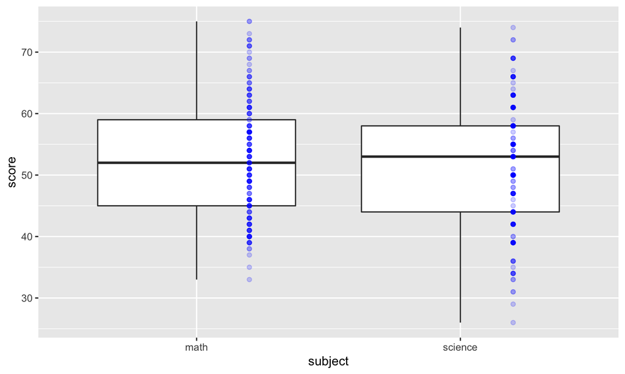

## Paired or not?

Can the math and science scores for a given student be assumed to be independent of each other?

| id | math | science | diff |
| --- | --- | --- | --- |
| 70 | 41 | 47 | -6 |
| 121 | 53 | 63 | -10 |
| 86 | 54 | 58 | -4 |
| 141 | 47 | 53 | -6 |

## Means of paired data

### Parameter of interest

\[\mu_{\text{diff}}\] Average difference between math and science scores of **all** students.

### Point estimator

\[\overline{x}_{\text{diff}}\] Average difference between math and science scores of 200 **sampled** students.

## Hypothesis test for paired data

\[H_0 : \mu_{\text{diff}} = 0\,, \quad \text{(there is no difference between scores)}\] \[\mathsf{vs}\] \[H_a : \mu_{\text{diff}} \neq 0\,, \quad \text{(there is a difference between scores)}\]

Calculate an appropriate test statistic for the *new* parameter \(\mu_{\text{diff}}\).

\[\overline{x}_{\text{diff}} = 0.795 \,,\quad s_{\text{diff}} = 8.2938 \,,\quad n_{\text{diff}} = 200\,. \]

Nothing new: carry out inference on a single sample population mean.

## Calculate test statistic

Let \(\alpha = 0.10\)

\(H_0 : \mu_{\text{diff}} = 0\)

\(H_a : \mu_{\text{diff}} \neq 0\)

\(\overline{x}_{\text{diff}} = 0.7950\)

\(s_{\text{diff}} = 8.2938\)

\(n_{\text{diff}} = 200\)

## Recap: \(P\)-values

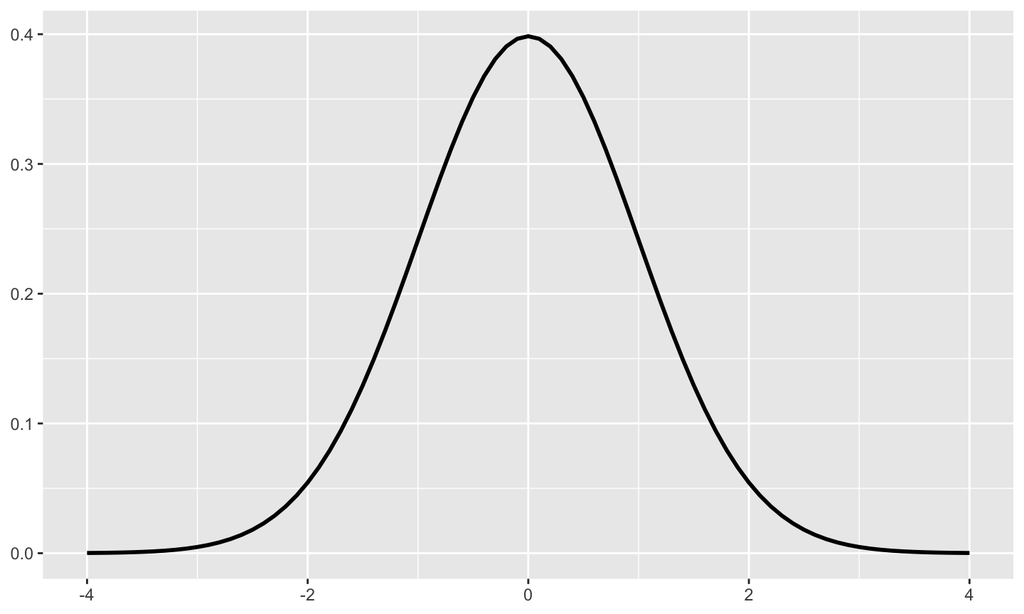

What is the correct interpretation of the \(P\)-value?

## Difference of two independent means

General interval estimate: \[\text{point estimate} \pm \text{margin of error}\]

Now for the parameter of interest \(\mu_{D} = \mu_{X} - \mu_{Y}\): \[(\overline{x} - \overline{y}) \pm t_{\alpha/2, \nu} \cdot \widehat{\sigma}_{(\overline{x} - \overline{y})}\]

Only new concept: \[\widehat{\sigma}_{(\overline{x} - \overline{y})} = \sqrt{\frac{s_x^2}{m} + \frac{s_y^2}{n}}\]

## Tricky parts…

### Complicated to compute true df!

A conservative estimate for the degrees of freedom \(\nu\) is \[\nu = \min(m-1, n-1)\,.\]

### Check conditions

1. Independence of samples both within and between groups.
2. Sample size and skew (more skewed distributions need larger number of samples).

## Summary

Today we discussed CI and hypothesis tests for:

- differences of means of paired observations
- differences of means of independent observations

from two different groups.